# Modeling - Renthop Data

Lateral Analytics

May 29, 2017

## Data modeling for the Renthop (Two Sigma Connect) Kaggle Competition

https://www.kaggle.com/c/two-sigma-connect-rental-listing-inquiries

## Remove all objects

```r
rm(list = ls())
```

## Load libraries

```r
# Clear any previously loaded packages
pkgs_1 = names(sessionInfo()$otherPkgs)
pkgs_2 = paste('package:', pkgs_1, sep = "")
invisible(if (length(pkgs_1) > 0){
  lapply(pkgs_2, detach, character.only = TRUE, unload = TRUE)
})
library("plyr")
library("tidyverse")
library("rjson")
library("rmarkdown")
library("lubridate")
library("ggplot2")
library("maps")
library("mapproj")
library("RColorBrewer")
library("wordcloud")
library("cluster")
library("stringr")
library("htmlwidgets")
## How to install rjava in preparation for syuzhet
## https://stackoverflow.com/questions/30572258/error-of-java-path-on-loading-rjava-package
library("syuzhet")
library("caret")
library("corrplot")
library("RANN")
library("MLmetrics")
library("doMC")
registerDoMC(cores = 1)
library("Boruta")
library("magrittr")
library("Matrix")
library("xgboost")
```

## Load data

```r
listings_4_trans <- readRDS(file = "../data/objects/listings_4_trans.rds")
```

## Investigate variable importance

```r
train_data <- listings_4_trans %>%
  filter(section == "train") %>%
  dplyr::select(-section,
         -listing_id)

test_data <- listings_4_trans %>%
  filter(section == "test") %>%
  dplyr::select(-interest_level,
         -section,
         -listing_id)

# For use with final submission
test_data_listing_id <- listings_4_trans %>%
  filter(section == "test") %>%
  dplyr::select(listing_id)

roc_values <- filterVarImp(x = train_data[,-c(1,2,3)],
                          y = train_data$interest_level)

roc_values <- as_tibble(rownames_to_column(roc_values))

roc_values$roc_avg = rowMeans(roc_values[,c(2:4)])

roc_values <- roc_values %>%
  arrange(-roc_avg)

print(roc_values)
```

```
## # A tibble: 40 x 5
##            rowname       low    medium      high   roc_avg
##              <chr>     <dbl>     <dbl>     <dbl>     <dbl>
##  1  hod_high_proba 0.6583104 0.6130592 0.6583104 0.6432267
##  2       created_h 0.6521448 0.6087449 0.6521448 0.6376782
##  3    groups_agnes 0.6330268 0.5950990 0.6330268 0.6203842
##  4    groups_clara 0.6104853 0.5995756 0.6104853 0.6068487
##  5      groups_pam 0.6113305 0.5917141 0.6113305 0.6047917
##  6           anger 0.5665362 0.5665362 0.5561623 0.5630783
##  7 beds_bath_ratio 0.5590842 0.5590842 0.5575479 0.5585721
##  8             joy 0.5554817 0.5554817 0.5405366 0.5505000
##  9        negative 0.5537014 0.5537014 0.5362753 0.5478927
## 10           trust 0.5527503 0.5527503 0.5348108 0.5467705
## # ... with 30 more rows
```

The highest AUC is 0.643 and is for hod_high_proba, which is the probability that a certain hour of day the listing was created will have a high interest level. This is followed by created_h (the hour of day a listing was created), and then the three geographical clustering methods. There are a fair number of features, which have an AUC below 0.5, which is problematic. This isn’t actually a two class problem, so this may have something to do with approximations.

### Run a simple Random Forest algorithm to see what variable importance values it produces.

```r
MultiLogLoss_summary <- function (data,
  lev = NULL,
  model = NULL) {
  out <- ModelMetrics::mlogLoss(data$obs, data[,c(3,4,5)])
  names(out) <- "MultiLogLoss"
  out
}


# prepare resampling method
cv_index <- createFolds(factor(train_data[,1]), 3, returnTrain = T)

ctrl <- trainControl(index = cv_index,
                     method="repeatedcv",
                     number=3,
                     repeats = 1,
                     classProbs=TRUE,
                     summaryFunction=MultiLogLoss_summary,
                     selectionFunction = "best",
                     allowParallel = TRUE,
                     verbose = FALSE,
                     sampling = "up",
                     savePredictions = 'final')

ranger_grid = expand.grid(mtry=seq(1.0, 10.0, 0.5))

set.seed(8)
fit_init <- train(y = train_data[,1],
             x = train_data[,-1],
             method="ranger",
             metric="MultiLogLoss",
             maximize = FALSE,
             trControl=ctrl,
             importance = "impurity",
             tuneGrid=ranger_grid)
# display results
print(fit_init)
```

```
## Random Forest
##
## 49352 samples
##    42 predictors
##     3 classes: 'low', 'medium', 'high'
##
## No pre-processing
## Resampling: Cross-Validated (3 fold, repeated 1 times)
## Summary of sample sizes: 32902, 32901, 32901
## Addtional sampling using up-sampling
##
## Resampling results across tuning parameters:
##
##   mtry  MultiLogLoss
##    1.0  0.8150791
##    1.5  0.8166746
##    2.0  0.6582480
##    2.5  0.6581638
##    3.0  0.6365493
##    3.5  0.6369667
##    4.0  0.6321385
##    4.5  0.6334032
##    5.0  0.6335762
##    5.5  0.6309683
##    6.0  0.6320542
##    6.5  0.6335212
##    7.0  0.6315327
##    7.5  0.6322804
##    8.0  0.6318734
##    8.5  0.6319928
##    9.0  0.6330551
##    9.5  0.6317524
##   10.0  0.6347560
##
## MultiLogLoss was used to select the optimal model using  the
##  smallest value.
## The final value used for the model was mtry = 5.5.
```

Those features most important within the model are below.

```r
varImp(fit_init)
```

```
## ranger variable importance
##
##   only 20 most important variables shown (out of 42)
##
##                       Overall
## price_bath_ratio       100.00
## agnes_price_diff        94.62
## price_photos_ratio      68.26
## price_feature_ratio     67.93
## listing_per_building    61.03
## sentiment_raw           55.11
## latitude                52.46
## long_med                47.81
## hod_high_proba          45.08
## lat_med                 44.81
## feat_photos_price_med   44.51
## created_h               43.15
## groups_pam              41.83
## positive                38.42
## groups_clara            37.97
## pam_med_price           36.15
## groups_agnes            35.24
## photos_count            34.99
## agnes_med_price         33.41
## beds_bath_ratio         33.31
```

### Run a Random Forest (Ranger) algorithm on just those features that had a ROC value greater than 0.5.

```r
roc_values_keep <- roc_values %>%
  filter(roc_avg > 0.5) %>%
  select(rowname)

roc_values_keep <- as.vector(roc_values_keep$rowname)




ctrl <- trainControl(index = cv_index,
                     method="repeatedcv",
                     number=3,
                     repeats = 1,
                     classProbs=TRUE,
                     summaryFunction=MultiLogLoss_summary,
                     selectionFunction = "best",
                     allowParallel = TRUE,
                     verbose = FALSE,
                     sampling = "up",
                     savePredictions = 'final')

ranger_grid = expand.grid(mtry=seq(1.0, 5.0, 0.2))

set.seed(8)
fit_roc <- train(y = train_data[,1],
             x = train_data[,roc_values_keep],
             method="ranger",
             metric="MultiLogLoss",
             maximize = FALSE,
             trControl=ctrl,
             importance = "impurity",
             tuneGrid=ranger_grid)
# display results
print(fit_roc)
```

```
## Random Forest
##
## 49352 samples
##    24 predictors
##     3 classes: 'low', 'medium', 'high'
##
## No pre-processing
## Resampling: Cross-Validated (3 fold, repeated 1 times)
## Summary of sample sizes: 32902, 32901, 32901
## Addtional sampling using up-sampling
##
## Resampling results across tuning parameters:
##
##   mtry  MultiLogLoss
##   1.0   0.9041830
##   1.2   0.9042087
##   1.4   0.9059260
##   1.6   0.9047813
##   1.8   0.9079410
##   2.0   0.7369253
##   2.2   0.7369959
##   2.4   0.7371793
##   2.6   0.7365941
##   2.8   0.7367623
##   3.0   0.7095282
##   3.2   0.7102329
##   3.4   0.7101327
##   3.6   0.7102402
##   3.8   0.7098447
##   4.0   0.7070593
##   4.2   0.7060318
##   4.4   0.7062679
##   4.6   0.7059937
##   4.8   0.7060440
##   5.0   0.7085253
##
## MultiLogLoss was used to select the optimal model using  the
##  smallest value.
## The final value used for the model was mtry = 4.6.
```

### Add some of the top features (variable importance > 50) based on variable importance in the ranger function with those that had and AUC > 0.5.

```r
varImp_keep <- varImp(fit_init)$importance %>%
  rownames_to_column(var = "rowname") %>%
  filter(Overall > 50)

roc_varImp_keep <- union(roc_values_keep,as.vector(varImp_keep$rowname))
```

```r
ctrl <- trainControl(index = cv_index,
                     method="repeatedcv",
                     number=3,
                     repeats = 1,
                     classProbs=TRUE,
                     summaryFunction=MultiLogLoss_summary,
                     selectionFunction = "best",
                     allowParallel = TRUE,
                     verbose = FALSE,
                     sampling = "up",
                     savePredictions = 'final')

ranger_grid = expand.grid(mtry=seq(1.0, 5.0, 0.2))

set.seed(8)
fit_roc_varImp <- train(y = train_data[,1],
             x = train_data[,roc_varImp_keep],
             method="ranger",
             metric="MultiLogLoss",
             maximize = FALSE,
             trControl=ctrl,
             importance = "impurity",
             tuneGrid=ranger_grid)
# display results
print(fit_roc_varImp)
```

```
## Random Forest
##
## 49352 samples
##    30 predictors
##     3 classes: 'low', 'medium', 'high'
##
## No pre-processing
## Resampling: Cross-Validated (3 fold, repeated 1 times)
## Summary of sample sizes: 32902, 32901, 32901
## Addtional sampling using up-sampling
##
## Resampling results across tuning parameters:
##
##   mtry  MultiLogLoss
##   1.0   0.8086095
##   1.2   0.8093531
##   1.4   0.8100322
##   1.6   0.8073019
##   1.8   0.8089741
##   2.0   0.6525763
##   2.2   0.6526127
##   2.4   0.6528534
##   2.6   0.6523214
##   2.8   0.6525424
##   3.0   0.6383844
##   3.2   0.6369118
##   3.4   0.6368030
##   3.6   0.6361331
##   3.8   0.6367837
##   4.0   0.6343507
##   4.2   0.6343347
##   4.4   0.6338978
##   4.6   0.6360061
##   4.8   0.6356753
##   5.0   0.6347767
##
## MultiLogLoss was used to select the optimal model using  the
##  smallest value.
## The final value used for the model was mtry = 4.4.
```

### Look for features with the Boruta package

```r
boruta_train <- Boruta(y = train_data[,1], x = train_data[,-1], doTrace = 0)
```

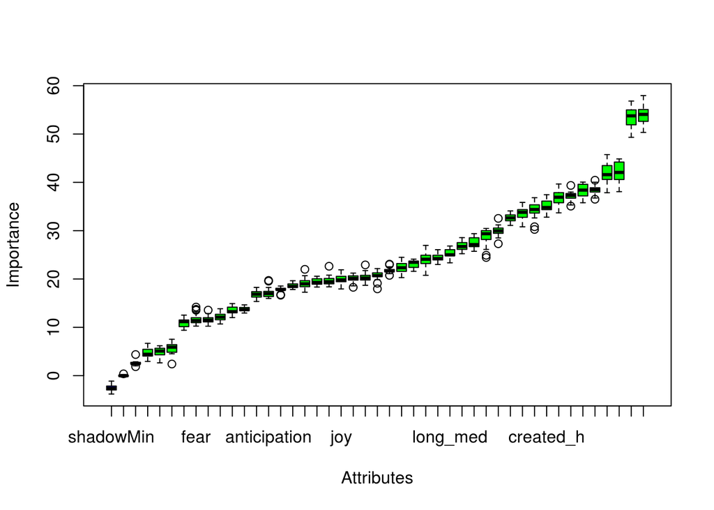

```r
plot(boruta_train)
```

The Boruta package says that everything is important. This isn’t useful. I’ll just use all features remaining at this point. This produces the best results and the algorithm doesn’t take too long to run.

Save the model for that run for later use.

```r
saveRDS(fit_init, file = "../data/objects/fit_init.rds")
```

## Modify data for use in xgBoost

```r
# Convert factor to integers

factor_cols <- c("created_dow", "price_thresh", "price_room_thresh", "top_manager", "top_building", "groups_agnes", "groups_pam", "groups_clara", "doorman")

train_data[,factor_cols] %<>% lapply(function(x) as.integer(x))

train_data_numeric <- train_data


test_data[,factor_cols] %<>% lapply(function(x) as.integer(x))

test_data_numeric <- test_data



# Treat interest_level separately to make sure the levels align to high, medium, and low properly.
train_data_numeric <- train_data_numeric %>%
  mutate(interest_level = as.integer(interest_level))



t1_sparse <- Matrix(as.matrix(train_data_numeric), sparse=TRUE)
labels <- as.numeric(train_data_numeric$interest_level-1)
#table(labels)

dtrain <- xgb.DMatrix(data=t1_sparse, label=labels)
```

## Initial xgBoost run

```r
param <- list(booster="gbtree",
              objective="multi:softprob",
              eval_metric="mlogloss",
              nthread=13,
              num_class=3,
              eta = .02,
              gamma = 1,
              max_depth = 4,
              min_child_weight = 1,
              subsample = .7,
              colsample_bytree = .5
)


xgb2 <- xgb.train(data = dtrain,
                  params = param,
                 # watchlist=watch,
                  # nrounds = xgb2cv$best_ntreelimit
                  nrounds = 2000
)
```

## Use xgBoost with it’s own cross validation function.

```r
xgb.grid <- expand.grid(nrounds = 500, #the maximum number of iterations
                        eta = c(0.01,0.1), # shrinkage
                        max_depth = c(2,6,10))

param <- list(booster="gbtree",
              objective="multi:softprob",
              eval_metric="mlogloss",
              nthread=13,
              num_class=3,
              eta = c(0.01,0.1),
              gamma = 1,
              max_depth = c(2,6,10),
              min_child_weight = 1,
              subsample = .7,
              colsample_bytree = .5
)

xgb2_cv <- xgb.cv(data = dtrain,
                  params = param,
                  nfold = 3,
                  showsd = TRUE,
                  stratified = TRUE,
                  nrounds = 3000,
                  verbose = FALSE,
                  early_stopping_rounds = TRUE)
```

## Use xgBoost with Caret for it’s grid search capabilities

```r
labels_xgBoost_caret <- make.names(labels)

MultiLogLoss_summary_xgBoost <- function (data,
  lev = NULL,
  model = NULL) {
  out <- ModelMetrics::mlogLoss(data$obs, data[,c(3,4,5)])
  names(out) <- "MultiLogLoss"
  out
}


# set up the cross-validated hyper-parameter search
xgb_grid_1 = expand.grid(
  nrounds = c(50, 100, 150),
  max_depth = c(1, 2, 3, 4),
  eta = c(0.1, 0.01, 0.001),
  gamma = 0,
  colsample_bytree = c(0.4, 0.6, 0.8, 1.0),
  min_child_weight = 1,
  subsample = c(0.25, 0.5, 0.75, 1.00)
)

# pack the training control parameters
xgb_trcontrol_1 = trainControl(
  method = "cv",
  number = 3,
  verboseIter = FALSE,
  returnData = FALSE,
  returnResamp = "all",
  classProbs = TRUE,
  summaryFunction=MultiLogLoss_summary_xgBoost,
  allowParallel = TRUE,
  savePredictions = 'final'
)


# train the model for each parameter combination in the grid,
#   using CV to evaluate
fit_xgb_train_1 = train(
  x = as.matrix(train_data_numeric[,-1]),
  y = labels_xgBoost_caret,
  trControl = xgb_trcontrol_1,
  tuneGrid = xgb_grid_1,
  method = "xgbTree",
  maximize = FALSE
)
```

Save xgb_train_1

```r
saveRDS(fit_xgb_train_1, file = "../data/objects/fit_xgb_train_1.rds")
```

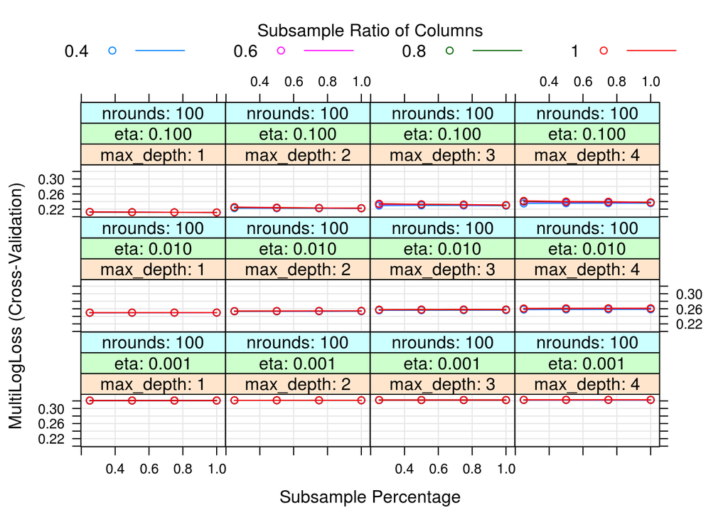

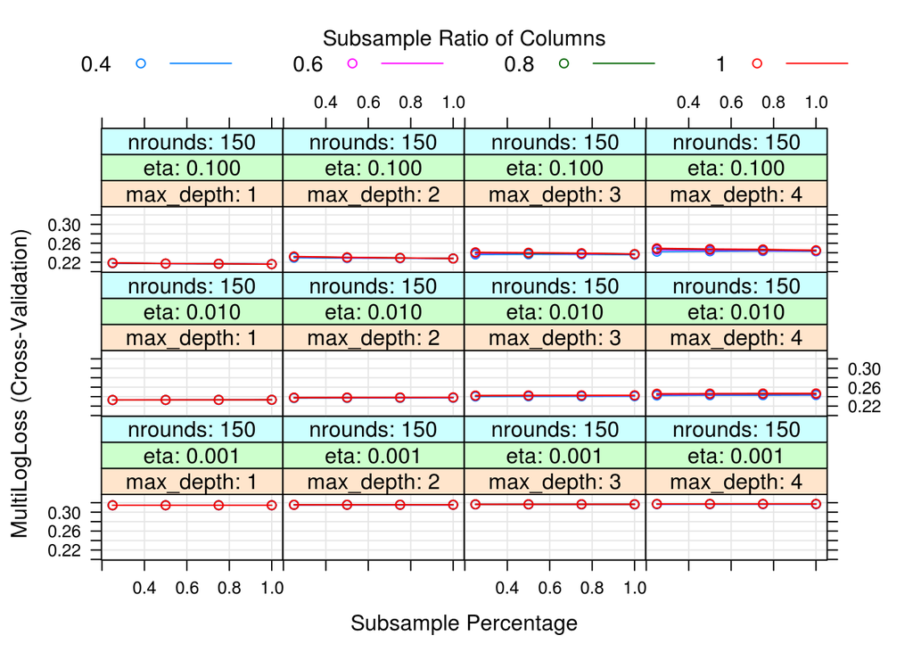

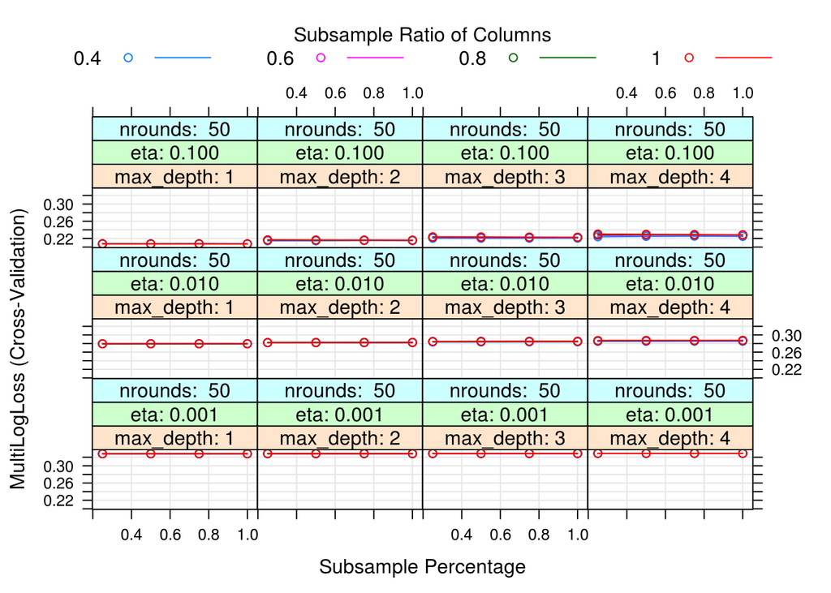

```r
plot(fit_xgb_train_1)
```

A higher value of eta is valuable as well as a lower value of max depth. The final model selected was for nrounds = 50, max_depth = 1, eta = 0.1, gamma = 0, colsample_bytree = 0.4, min_child_weight = 1 and subsample = 0.5.

```r
fit_xgb_train_1$results %>% arrange(MultiLogLoss)
```

```
##       eta max_depth gamma colsample_bytree min_child_weight subsample
## 1   0.100         1     0              0.4                1      0.50
## 2   0.100         1     0              0.4                1      1.00
## 3   0.100         1     0              0.8                1      1.00
## 4   0.100         1     0              1.0                1      1.00
## 5   0.100         1     0              0.6                1      0.50
## 6   0.100         1     0              0.6                1      0.25
## 7   0.100         1     0              0.6                1      1.00
## 8   0.100         1     0              1.0                1      0.25
## 9   0.100         1     0              1.0                1      0.75
## 10  0.100         1     0              0.6                1      0.75
## 11  0.100         1     0              1.0                1      0.50
## 12  0.100         1     0              0.4                1      0.75
## 13  0.100         1     0              0.4                1      0.25
## 14  0.100         1     0              0.8                1      0.50
```

[output cut: 1139 more lines]

This brings a multiLogLoss value of 0.2072540, which is much smaller than that from the ranger algorithm. The highest score on the Kaggle leaderboard is 0.49194, so I don’t believe this number. Perhaps I need to make some changes with the metric or the cross-validation settings? Nevertheless, it still has predictive power. Let’s move on.

## Use a GBM model on this data.

```r
MultiLogLoss_summary_GBM <- function (data,
  lev = NULL,
  model = NULL) {
  out <- ModelMetrics::mlogLoss(data$obs, data[,c(3,4,5)])
  names(out) <- "MultiLogLoss"
  out
}




# pack the training control parameters
GBM_trcontrol_1 = trainControl(
  method = "cv",
  number = 3,
  verboseIter = FALSE,
  returnData = FALSE,
  returnResamp = "all",
  classProbs = TRUE,
  summaryFunction=MultiLogLoss_summary_GBM,
  allowParallel = TRUE,
  savePredictions = 'final'
)


# train the model for each parameter combination in the grid,
#   using CV to evaluate
fit_GBM_train_1 = train(
  x = train_data[,-1],
  y = train_data[,1],
  trControl = GBM_trcontrol_1,
  method = "gbm",
  maximize = FALSE
)
```

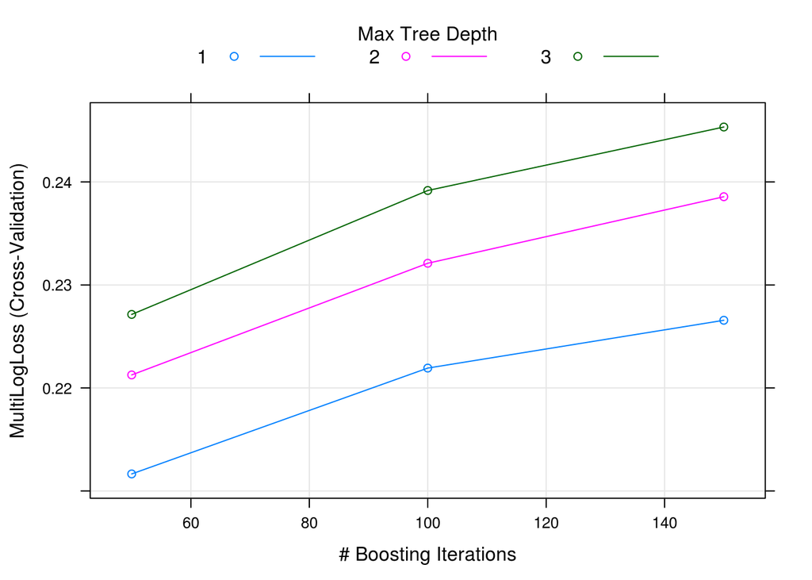

```r
plot(fit_GBM_train_1)
```

```r
fit_GBM_train_1$results %>% arrange(MultiLogLoss)
```

```
##   shrinkage interaction.depth n.minobsinnode n.trees MultiLogLoss
## 1       0.1                 1             10      50    0.2116510
## 2       0.1                 2             10      50    0.2212639
## 3       0.1                 1             10     100    0.2219290
## 4       0.1                 1             10     150    0.2265696
## 5       0.1                 3             10      50    0.2271376
## 6       0.1                 2             10     100    0.2321060
## 7       0.1                 2             10     150    0.2385664
## 8       0.1                 3             10     100    0.2391704
## 9       0.1                 3             10     150    0.2453342
##   MultiLogLossSD
## 1   6.240527e-04
## 2   1.159506e-03
## 3   9.011484e-05
## 4   6.846206e-04
## 5   8.727580e-04
## 6   7.705533e-04
## 7   1.406765e-03
## 8   7.046187e-04
## 9   8.672572e-04
```

```r
saveRDS(fit_GBM_train_1, file = "../data/objects/fit_GBM_train_1.rds")
```

## Stacking

```r
fit_init <- readRDS(file = "../data/objects/fit_init.rds")
fit_xgb_train_1 <- readRDS(file = "../data/objects/fit_xgb_train_1.rds")
fit_GBM_train_1 <- readRDS(file = "../data/objects/fit_GBM_train_1.rds")
```

```r
#Predict the out of fold prediction probabilities for the training data

OOF_pred_rf_train <- fit_init$pred %>% arrange(rowIndex) %>% select(low, medium, high) %>% rename(low_rf = low, medium_rf = medium, high_rf = high)
OOF_pred_xgb_train <- fit_xgb_train_1$pred %>% arrange(rowIndex) %>% select(X0, X1, X2) %>% rename(low_xgb = X0, medium_xgb = X1, high_xgb = X2)
OOF_pred_GBM_train <- fit_GBM_train_1$pred %>% arrange(rowIndex) %>% select(low, medium, high) %>% rename(low_GBM = low, medium_GBM = medium, high_GBM = high)
train_set <- as_tibble(c(data.frame(train_data$interest_level), OOF_pred_rf_train, OOF_pred_xgb_train, OOF_pred_GBM_train))
train_set <- train_set %>% rename(interest_level = train_data.interest_level)




# Predict the prediction probabilities for the test data.

OOF_pred_rf_test <- predict(fit_init,test_data,type='prob') %>% select(low, medium, high) %>% rename(low_rf = low, medium_rf = medium, high_rf = high)
OOF_pred_xgb_test <- predict(fit_xgb_train_1,test_data_numeric,type='prob') %>% select(X0, X1, X2) %>% rename(low_xgb = X0, medium_xgb = X1, high_xgb = X2)
OOF_pred_GBM_test <- predict(fit_GBM_train_1,test_data_numeric,type='prob') %>% select(low, medium, high) %>% rename(low_GBM = low, medium_GBM = medium, high_GBM = high)
test_set <- as_tibble(c(OOF_pred_rf_test, OOF_pred_xgb_test, OOF_pred_GBM_test))
```

### Run a model on top of the three initial model predictions

```r
#labels_nn <- make.names(train_set$interest_level)
labels_nn <- make.names(as.numeric(train_set$interest_level)-1)

MultiLogLoss_summary_nn <- function (data,
  lev = NULL,
  model = NULL) {
  out <- ModelMetrics::mlogLoss(data$obs, data[,c(3,4,5)])
  names(out) <- "MultiLogLoss"
  out
}

# pack the training control parameters
nn_trcontrol_1 = trainControl(
  method = "cv",
  number = 3,
  verboseIter = TRUE,
  returnData = FALSE,
  returnResamp = "all",
  classProbs = TRUE,
  summaryFunction=MultiLogLoss_summary_nn,
  allowParallel = TRUE,
  savePredictions = 'final'
)

# Use CV to evaluate
fit_nn_train_1 = train(
  y = labels_nn,
  x = train_set[,-1],
  trControl = nn_trcontrol_1,
  method = "avNNet",
  maximize = FALSE
)
```

[output not shown]

[output cut: 225 more lines]

[output not shown]

```r
saveRDS(fit_nn_train_1, file = "../data/objects/fit_nn_train_1.rds")
```

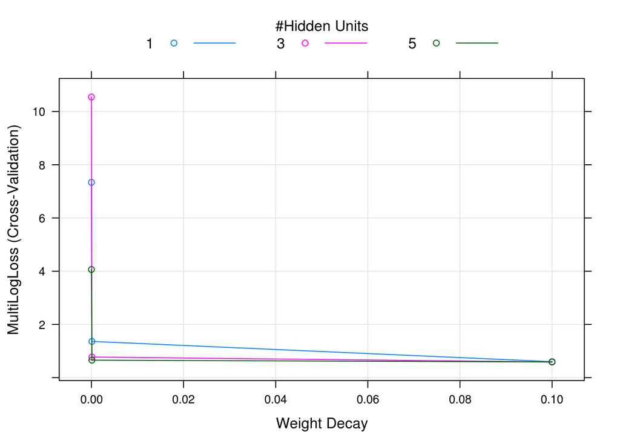

```r
plot(fit_nn_train_1)
```

The lowest multiLogLoss value was 0.5883, which was consistent with the results on the Kaggle leaderboard.

## Prepare submission for Kaggle

```r
pred_nn_final <- predict(fit_nn_train_1,test_set,type='prob') %>% rename(low = X0, medium = X1, high = X2) %>%
  select(high, medium, low)

renthop_submission <- as_tibble(c(test_data_listing_id, pred_nn_final))

write.csv(renthop_submission, file = "../submissions/renthop_submission.csv", row.names=FALSE)
write.csv(renthop_submission, file=gzfile("../submissions/renthop_submission.csv.gz"), row.names=FALSE)
```

The final score on the Kaggle test set was 0.58922.